# 收集数据

### 检验

```python
tweet_archive_clean["rating_denominator"].value_counts()
```

```
10     2334
50        3
80        2
20        2
15        1
7         1
170       1
150       1
130       1
120       1
110       1
90        1
70        1
40        1
16        1
Name: rating_denominator, dtype: int64
```

tweet_archive:

- 诸多列存在数据格式不正确的问题

```python
tweet_archive_clean.info()
```

```
<class 'pandas.core.frame.DataFrame'>
Int64Index: 2352 entries, 0 to 2351
Data columns (total 15 columns):
tweet_id                      2352 non-null object
type                          2352 non-null object
status_id                     255 non-null object
status_user_id                255 non-null object
timestamp                     2352 non-null datetime64[ns]
retweeted_status_timestamp    177 non-null datetime64[ns]
source                        2352 non-null category
text                          2352 non-null object
expanded_urls                 2352 non-null object
rating_numerator              2352 non-null int64
rating_denominator            2352 non-null int64
name                          2352 non-null object
stage                         2352 non-null object
favorite                      2352 non-null int64
retweet_count                 2352 non-null int64
dtypes: category(1), datetime64[ns](2), int64(4), object(8)
memory usage: 358.1+ KB
```

```python
tweet_archive_clean["type"]=tweet_archive_clean["type"].astype("category")
```

### 检验

```python
tweet_archive_clean.info()
```

```
<class 'pandas.core.frame.DataFrame'>
Int64Index: 2352 entries, 0 to 2351
Data columns (total 15 columns):
tweet_id                      2352 non-null object
type                          2352 non-null category
status_id                     255 non-null object
status_user_id                255 non-null object
timestamp                     2352 non-null datetime64[ns]
retweeted_status_timestamp    177 non-null datetime64[ns]
source                        2352 non-null category
text                          2352 non-null object
expanded_urls                 2352 non-null object
rating_numerator              2352 non-null int64
rating_denominator            2352 non-null int64
name                          2352 non-null object
stage                         2352 non-null object
favorite                      2352 non-null int64
retweet_count                 2352 non-null int64
dtypes: category(2), datetime64[ns](2), int64(4), object(7)
memory usage: 342.1+ KB
```

**image_recongnition:**

- 多个图片链接重复出现
- tweet_id数据类型不正确

### 定义

去除重复项  
更正数据类型

### 代码

```python
image_recognition_clean.drop_duplicates(["jpg_url"],inplace=True)
image_recognition_clean["tweet_id"]=image_recognition_clean["tweet_id"].astype("str")
```

### 检验

```python
image_recognition_clean["jpg_url"].duplicated().any()
```

```
False
```

```python
image_recognition_clean.info()
```

```
<class 'pandas.core.frame.DataFrame'>
Int64Index: 2009 entries, 0 to 2074
Data columns (total 12 columns):
tweet_id    2009 non-null object
jpg_url     2009 non-null object
img_num     2009 non-null int64
p1          2009 non-null object
p1_conf     2009 non-null float64
p1_dog      2009 non-null bool
p2          2009 non-null object
p2_conf     2009 non-null float64
p2_dog      2009 non-null bool
p3          2009 non-null object
p3_conf     2009 non-null float64
p3_dog      2009 non-null bool
dtypes: bool(3), float64(3), int64(1), object(5)
memory usage: 162.8+ KB
```

**tweet_archive:**

- Name一列存在叫做a、an、my、the、this、his、actually、incredibly、O、such、light、life的。

### 定义

方法是通过将这些名字不对的记录筛选出来，导出到excel中查看筛选，并用函数将其名字取出，将结果保存在python列表中，并用python的循环功能更正

```python
ind=[1849,1951,1990,2030,2062,2112,2121,2124,2142,2157,2187,2214,2231,2245,2251,2260,2269,2283,2300,2307,2310,848,2200]
names=['Wylie','Kip','Rand','Jacob','Rufus','Spork','Cherokee','Hemry','Alphred','Alfredo','Leroi','Chuk','Alfonso','Cheryl','Jessiga','Klint','Kohl','Daryl','Pepe','Octaviath','Johm', 'Zoey', 'Berta']
```

```python
for i in range(len(ind)):
    tweet_archive_clean["name"][ind[i]]=names[i]
```

```python
#更正名字为O的记录
tweet_archive_clean["name"]=tweet_archive_clean["name"].replace("O","O'Malley")
#清理名字为the的记录
tweet_archive_clean["name"][2342]="Rand"
tweet_archive_clean["name"]=tweet_archive_clean["name"].replace("the","None")
```

```python
tweet_archive_clean["name"]=tweet_archive_clean["name"].replace("a","None").replace("an","None").replace("quite","None").replace("such","None")
tweet_archive_clean["name"]=tweet_archive_clean["name"].replace("officially","None").replace("unacceptable","None").replace("mad","None").replace("by","None").replace("one","None").replace("this","None")
```

```python
tweet_archive_clean["name"][988]="Quizno"
```

### 检验

```python
tweet_archive_clean["name"].value_counts()
```

```
None        797
Charlie      12
Lucy         11
Cooper       11
Oliver       11
Lola         10
Tucker       10
Penny        10
Bo            9
Winston       9
Sadie         8
Daisy         7
Bailey        7
Buddy         7
Toby          7
Jack          6
Rusty         6
Leo           6
Koda          6
Scout         6
Dave          6
Oscar         6
Stanley       6
Jax           6
Bella         6
Milo          6
George        5
Finn          5
Chester       5
Oakley        5
           ...
Katie         1
Herb          1
Alf           1
Meatball      1
Pupcasso      1
Hall          1
Creg          1
Shelby        1
Maxwell       1
Fido          1
Shadoe        1
Peanut        1
Durg          1
Dudley        1
Patch         1
Rascal        1
Tassy         1
Brandy        1
Pawnd         1
Sprout        1
Ambrose       1
Johm          1
Skittle       1
Rhino         1
Farfle        1
Jett          1
Pilot         1
Taz           1
Wishes        1
Holly         1
Name: name, Length: 971, dtype: int64
```

addtional_info:

- Favorite_count中存在大量为0的数据

### 定义

由于将其丢弃会对其他列数据产生较大影响，将其填充为空值

### 代码

```python
tweet_archive_clean["favorite"]=tweet_archive_clean["favorite"].replace(0,np.nan)
```

### 检验

```python
tweet_archive_clean.shape
```

```
(2352, 15)
```

```python
tweet_archive_clean.query("favorite==0")
```

|  | tweet_id | type | status_id | status_user_id | timestamp | retweeted_status_timestamp | source | text | expanded_urls | rating_numerator | rating_denominator | name | stage | favorite | retweet_count |
| --- | --- | --- | --- | --- | --- | --- | --- | --- | --- | --- | --- | --- | --- | --- | --- |

**tweet_archive:**

- rating_numerator、rating_denominator两列存在着对一次多只狗狗评分的情况，导致评分分母大于10的情况。同时存在评分分母不为10的情况。标准不一致

### 定义

将两行相除，得到新的rating

### 代码

```python
tweet_archive_clean["rating"]=tweet_archive_clean["rating_numerator"].divide(tweet_archive_clean["rating_denominator"])
tweet_archive_clean.drop(columns=["rating_numerator","rating_denominator"],inplace=True)
```

### 检验

```python
tweet_archive_clean.head()
```

|  | tweet_id | type | status_id | status_user_id | timestamp | retweeted_status_timestamp | source | text | expanded_urls | name | stage | favorite | retweet_count | rating |
| --- | --- | --- | --- | --- | --- | --- | --- | --- | --- | --- | --- | --- | --- | --- |
| 0 | 892420643555336193 | original | NaN | NaN | 2017-08-01 16:23:56 | NaT | Twitter for iPhone | This is Phineas. He's a mystical boy. Only eve... | https://twitter.com/dog_rates/status/892420643... | Phineas | None | 39492.0 | 8842 | 1.3 |
| 1 | 892177421306343426 | original | NaN | NaN | 2017-08-01 00:17:27 | NaT | Twitter for iPhone | This is Tilly. She's just checking pup on you.... | https://twitter.com/dog_rates/status/892177421... | Tilly | None | 33786.0 | 6480 | 1.3 |
| 2 | 891815181378084864 | original | NaN | NaN | 2017-07-31 00:18:03 | NaT | Twitter for iPhone | This is Archie. He is a rare Norwegian Pouncin... | https://twitter.com/dog_rates/status/891815181... | Archie | None | 25445.0 | 4301 | 1.2 |
| 3 | 891689557279858688 | original | NaN | NaN | 2017-07-30 15:58:51 | NaT | Twitter for iPhone | This is Darla. She commenced a snooze mid meal... | https://twitter.com/dog_rates/status/891689557... | Darla | None | 42863.0 | 8925 | 1.3 |
| 4 | 891327558926688256 | original | NaN | NaN | 2017-07-29 16:00:24 | NaT | Twitter for iPhone | This is Franklin. He would like you to stop ca... | https://twitter.com/dog_rates/status/891327558... | Franklin | None | 41016.0 | 9721 | 1.2 |

## 再次评估清理好的数据

```python
tweet_archive_clean.info()
```

```
<class 'pandas.core.frame.DataFrame'>
Int64Index: 2352 entries, 0 to 2351
Data columns (total 14 columns):
tweet_id                      2352 non-null object
type                          2352 non-null category
status_id                     255 non-null object
status_user_id                255 non-null object
timestamp                     2352 non-null datetime64[ns]
retweeted_status_timestamp    177 non-null datetime64[ns]
source                        2352 non-null category
text                          2352 non-null object
expanded_urls                 2352 non-null object
name                          2352 non-null object
stage                         2352 non-null object
favorite                      2175 non-null float64
retweet_count                 2352 non-null int64
rating                        2352 non-null float64
dtypes: category(2), datetime64[ns](2), float64(2), int64(1), object(7)
memory usage: 323.8+ KB
```

```python
image_recognition_clean.info()
```

```
<class 'pandas.core.frame.DataFrame'>
Int64Index: 2009 entries, 0 to 2074
Data columns (total 12 columns):
tweet_id    2009 non-null object
jpg_url     2009 non-null object
img_num     2009 non-null int64
p1          2009 non-null object
p1_conf     2009 non-null float64
p1_dog      2009 non-null bool
p2          2009 non-null object
p2_conf     2009 non-null float64
p2_dog      2009 non-null bool
p3          2009 non-null object
p3_conf     2009 non-null float64
p3_dog      2009 non-null bool
dtypes: bool(3), float64(3), int64(1), object(5)
memory usage: 162.8+ KB
```

### 质量

#### 合理性：

tweet_archive_clean:

- stage一列中存在doggo,pupper和doggo,puppo这样的类型，按照定义一只狗不可能同时是doggo或者pupper等。

### 整洁度

tweet_archive_clean:

- timestamp、retweeted_status_timestamp的年月日不同单位变量位于一列中，应该分开

### 整洁度

tweet_archive_clean:

- timestamp、retweeted_status_timestamp的年月日不同单位变量位于一列中，应该分开

### 定义

根据年月日及小时和星期，将timestamp拆分为不同的列,同时retweeted_status_timestamp不需要用于分析，将其丢弃。

### 代码

```python
tweet_archive_clean["timestamp_year"]=tweet_archive_clean["timestamp"].dt.year
tweet_archive_clean["timestamp_month"]=tweet_archive_clean["timestamp"].dt.month
tweet_archive_clean["timestamp_day"]=tweet_archive_clean["timestamp"].dt.day
tweet_archive_clean["timestamp_hour"]=tweet_archive_clean["timestamp"].dt.hour
tweet_archive_clean["timestamp_weekday"]=tweet_archive_clean["timestamp"].dt.weekday
```

```python
tweet_archive_clean.drop(columns=["retweeted_status_timestamp"],inplace=True)
```

### 检验

```python
tweet_archive_clean.head()
```

|  | tweet_id | type | status_id | status_user_id | timestamp | source | text | expanded_urls | name | stage | favorite | retweet_count | rating | timestamp_year | timestamp_month | timestamp_day | timestamp_hour | timestamp_weekday |
| --- | --- | --- | --- | --- | --- | --- | --- | --- | --- | --- | --- | --- | --- | --- | --- | --- | --- | --- |
| 0 | 892420643555336193 | original | NaN | NaN | 2017-08-01 16:23:56 | Twitter for iPhone | This is Phineas. He's a mystical boy. Only eve... | https://twitter.com/dog_rates/status/892420643... | Phineas | None | 39492.0 | 8842 | 1.3 | 2017 | 8 | 1 | 16 | 1 |
| 1 | 892177421306343426 | original | NaN | NaN | 2017-08-01 00:17:27 | Twitter for iPhone | This is Tilly. She's just checking pup on you.... | https://twitter.com/dog_rates/status/892177421... | Tilly | None | 33786.0 | 6480 | 1.3 | 2017 | 8 | 1 | 0 | 1 |
| 2 | 891815181378084864 | original | NaN | NaN | 2017-07-31 00:18:03 | Twitter for iPhone | This is Archie. He is a rare Norwegian Pouncin... | https://twitter.com/dog_rates/status/891815181... | Archie | None | 25445.0 | 4301 | 1.2 | 2017 | 7 | 31 | 0 | 0 |
| 3 | 891689557279858688 | original | NaN | NaN | 2017-07-30 15:58:51 | Twitter for iPhone | This is Darla. She commenced a snooze mid meal... | https://twitter.com/dog_rates/status/891689557... | Darla | None | 42863.0 | 8925 | 1.3 | 2017 | 7 | 30 | 15 | 6 |
| 4 | 891327558926688256 | original | NaN | NaN | 2017-07-29 16:00:24 | Twitter for iPhone | This is Franklin. He would like you to stop ca... | https://twitter.com/dog_rates/status/891327558... | Franklin | None | 41016.0 | 9721 | 1.2 | 2017 | 7 | 29 | 16 | 5 |

### 质量

#### 合理性：

tweet_archive_clean:

- stage一列中存在doggo,pupper和doggo,puppo这样的类型，按照定义一只狗通常不会同时是doggo或者pupper等

### 定义

检查后发现有些是一张照片同时存在doggo和pupper或puppo，有些则是程序对推文的识别错误问题，经整理后有如下需要更改的地方：

- 行188需要更改为puppo
- 行197需要更改为floofer
- 行457需要更改为pupper
- 行572需要更改为pupper
- 行702需要更改为doggo
- 行952需要更改为doggo

```python
tweet_archive_clean["stage"][188]="puppo"
tweet_archive_clean["stage"][197]="floofer"
tweet_archive_clean["stage"][457]="pupper"
tweet_archive_clean["stage"][572]="pupper"
tweet_archive_clean["stage"][702]="doggo"
tweet_archive_clean["stage"][952]="doggo"
```

### 检验

```python
print(tweet_archive_clean["stage"][188])
print(tweet_archive_clean["stage"][197])
print(tweet_archive_clean["stage"][457])
print(tweet_archive_clean["stage"][572])
print(tweet_archive_clean["stage"][702])
print(tweet_archive_clean["stage"][952])
```

```
puppo
floofer
pupper
pupper
doggo
doggo
```

## 保存已清洗的数据

```python
tweet_archive_clean.merge(image_recognition_clean,how="left",on="tweet_id").to_csv("twitter_archive_master.csv")
```

## 可视化展示

```python
import matplotlib.pyplot as plt
import seaborn as sns
```

```python
%matplotlib inline
```

```python
sns.set_style("darkgrid")
```

### 该推特主的活跃时间

```
Text(0,0.5,'Tweets Number')
```

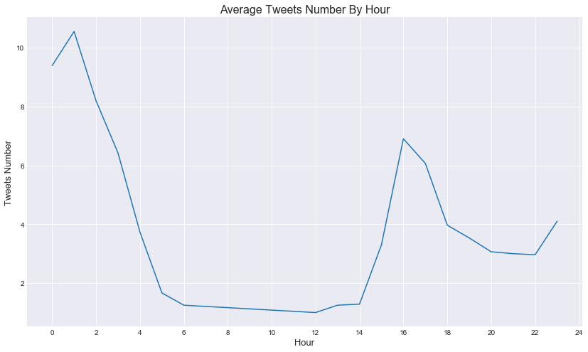

```python
tweet_archive_clean.groupby(["timestamp_day","timestamp_hour"])["tweet_id"].count().to_frame()\
.reset_index("timestamp_hour").groupby(["timestamp_hour"])["tweet_id"].mean().plot(figsize=(14,8)).locator_params("x",nbins=20);
plt.title("average tweets number by hour".title(),size=16)
plt.xlabel("Hour",size=13)
plt.ylabel("Tweets Number",size=13)
```

该推特主的主要活跃时间在格林威治时间(由原数据的+0000)的晚上22点至次日凌晨4点以及下午14点至18点之间，这大致对应于美国时间的上午9-13点及下午17点-晚上23点（以UTC-5），可见该推特主主要在上午和下午17点以后的时间比较活跃。

```
Text(0.5,1,'Average Tweets Number By Weekdays')
```

[figure not shown]

```python
tweet_archive_clean.groupby(["timestamp_day","timestamp_weekday"])["tweet_id"].count().to_frame().reset_index("timestamp_weekday").\
groupby(["timestamp_weekday"])["tweet_id"].mean().plot(kind="bar",figsize=(14,8))
plt.xticks([0,1,2,3,4,5,6],["Sun","Mon","Tue","Wed","Thu","Fri","Sat"],fontsize=12,rotation=0);
plt.xlabel("Weekday",fontsize=13)
plt.ylabel("Tweets Number",fontsize=13)
plt.title("Average tweets number by weekdays".title(),fontsize=16)
```

### 推特的类型占比

```python
import matplotlib as mpl
mpl.rcParams['font.size']=15
```

```
Text(0.5,1,'The Type Of Tweets')
```

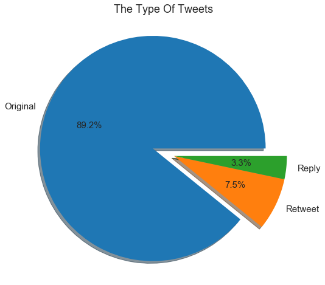

```python
plt.figure(figsize=(8,8))
size=tweet_archive_clean["type"].value_counts().values
labels=["Original","Retweet","Reply"]
explode=[0.2,0,0]
plt.pie(size,explode=explode,labels=labels,autopct='%1.1f%%',shadow=True);
plt.axis("equal");
plt.title("the type of tweets".title())
```

从这个数据来看，尽管该推特主主要是回应其他用户的评分请求，但其很少直接去回复或转发他人的推特。对他人的评分请求的回应主要以原创推特的形式发出，这可能是该博主的一种保护用户隐私的行为。

### 推特主的评分习惯

```
 <a list of 1 Text xticklabel objects>)
```

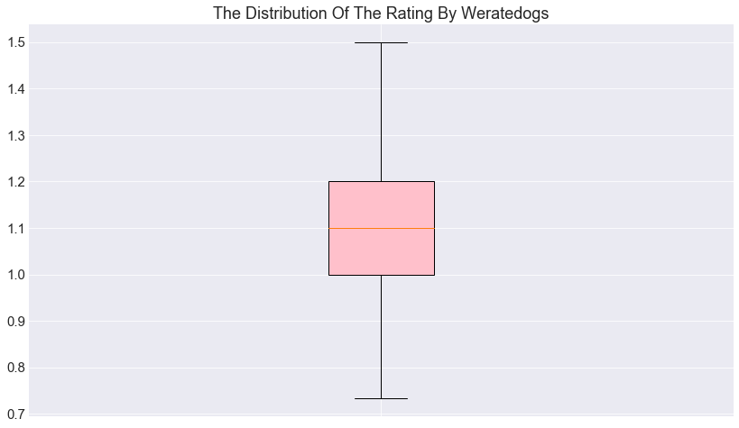

```python
plt.figure(figsize=(14,8))
plt.boxplot(tweet_archive_clean["rating"],showfliers=False,patch_artist=True,boxprops={'facecolor':'pink'});
plt.title("the distribution of the rating by weratedogs".title())
plt.xticks([1],[""])
```

从上图来看，该博主最常给出的分数大约是在1.0-1.2之间，也就是10/10-12/10之间。大致上说，高于12/10就算是比较高的分数了，而低于10/10则是比较低。上图为了让图像更清晰地显示，已经去除了离群值。一般来说，打分高于15/10的是非常罕见的。

### 狗狗最常用的名字有哪些？

```python
import wordcloud
```

```python
def to_str(series):
    s=""
    for i in series:
        s=s+i+","
    return s
```

```
<function matplotlib.pyplot.show>
```

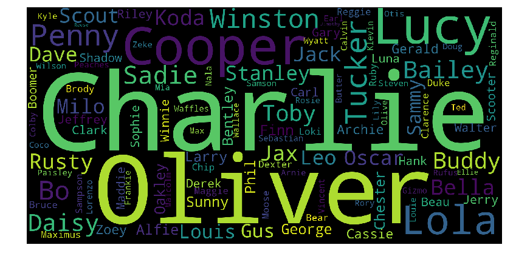

```python
s=to_str(tweet_archive_clean.query("name!=\'None\'")["name"])
w=wordcloud.WordCloud(scale=5).generate(s)
plt.figure(figsize=(14,8))
plt.imshow(w)
plt.axis("off")
plt.show
```

### 哪种狗狗的评分以及获赞数最多？

```
Text(0.5,1,'The Rating By Different Stage')
```

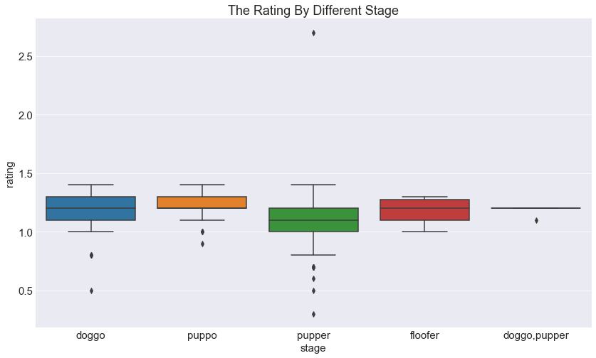

```python
stage=tweet_archive_clean.query("stage!=\'None\'")
plt.figure(figsize=(14,8))
sns.boxplot(x=stage["stage"],y=stage["rating"],data=stage);
plt.title("the rating by different stage".title())
```

这个博主给puppo的分数似乎总体比其他类的狗狗更高一些，这是否说明这个博主更偏爱puppo、更容易给puppo比较高的分数？由于推文中大部分并未声明其狗狗属于哪一类，因此此处能获取的数据仅仅是少数，需要更进一步使用推断统计工具后才能做出更有把握的说明。

```
Text(0.5,1,'The Favorite Counts By Different Stage')
```

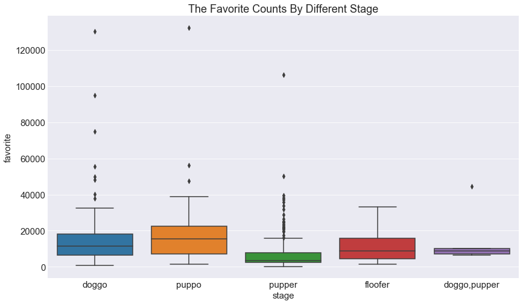

```python
stage=tweet_archive_clean.query("stage!=\'None\'")
plt.figure(figsize=(14,8))
sns.boxplot(x=stage["stage"],y=stage["favorite"],data=stage);
plt.title("the favorite counts by different stage".title())
```

此处同样显示puppo获得的赞大体上要比其他狗狗略高一些，但由于样本数量有限，同样很难就此断定人们更爱puppo多一点。

### 评分与获赞数、转发数有无关联？

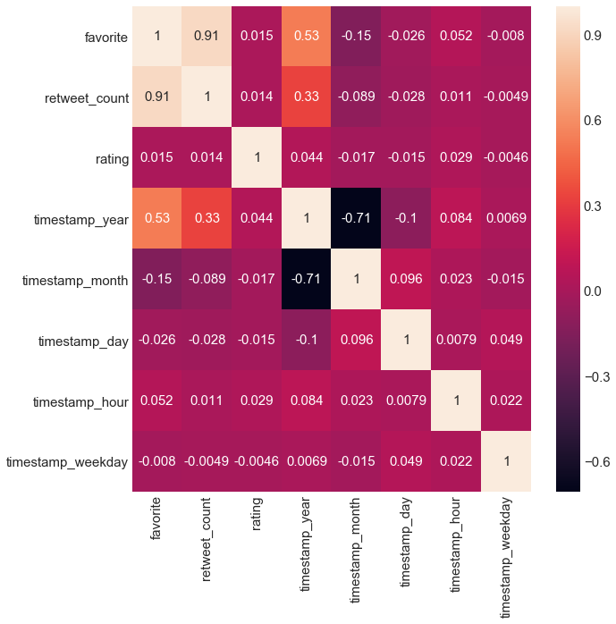

```python
plt.figure(figsize=(10,10))
df1=tweet_archive_clean.corr()
sns.heatmap(df1,annot=True)
```

我们发现评分与转发数之间并无明显的关联性，从时间上来说，评分是在转发和获赞之前，这个结果说明给出的评分更高的推特，并不见得就会相应地有更多的转发或者更多的赞（当然也不见得更少）。